# study Knitr

学习 knitr和 rmarkdown的一些语法

Go back

# study Knitr

YuDalang

2016-08-20

```r
knitr::opts_chunk$set(echo = TRUE,prompt = T)
#global setting e.g. if you want to set prompt = T for defalut,than you can set in here
#there is an arguement here *include* if you set T, than you can see this command,so as F
```

# The basic symbol

1. I use list(markdown grammar) to show this context.
2. *,-,+ the effect of three are the same, there are called the Markdown symbol
3. the blank line means stat a new paragraph also means trun to a new line  
   **the continuous two spacebars** also means a new line
4. ` represent ‘inline’

# The basic statement

- *italic* means the R code
  - If you use italic you should print *your content* warning: No spacebar after *
- **bold** means my personal understanding
  - If you use bold you should print **your content**
- If you insert new lines you should print *# + spacebar + a blank new line up and down*
- delete means my post misunderstanding
  - If you use delete-line you should print *~~your content~~*

```
    * If you use separator you should print * * * ,but remember to skip lines up and down
```

# 1. title:

you need to know is that there are two type of the grammer in for the title:the Setext-like and atx-like

I just need to know the latter one atx-like.**The maximum is six #(pounds)**

*#This is the title use one pound*

# This is the title use one pound

*##This is the title use two pounds*

## This is the title use two pounds

*###This is the title use three pounds*

### This is the title use three pounds

# 2. reference or blockquote or annotation

Use > to do so. example *>my first reference*

> my first reference

# 3. list

- *,+,- plus a space key  
  e.g. *your content
- support nest use - first + nest **indenting list items by two spaces and one Tab**
1. nest1
2. nest2
- out1
  - in1
  - in2
- out1
- you can use digital + dot +spacebar e.g. *1. your content*
- if your content is very long, you don’t need to change to a new line manually

# 4. link

you can use the follow way if your links are few. If large you can search the Internet! e.g. *[baidu]$(https://www.baidu.com/$)*

[baidu](https://www.baidu.com/)

# 5. image

e.g.

```
![picName](/path/to/img.jpg)
```

# 6. code

1. if your code is small use *` your code `*, ` symbol is on your Tab key

`use warnings`

2. you can also use ``` to wrap some code and assign a computer language

e.g. *``` perl $a=1;$b=$a+1 ```*

```perl
 $a=1;
 $b=$a+1;
```

3. And your can use **four spacebar** and **tab** to substitute the ```

# 7. table

following is the table code, it as widly aknowledged that use of table is annoyed

```
| Tables        | Are           | Cool  |
| ------------- |:-------------:| -----:|
| col 3 is      | right-aligned | $1600 |
| col 2 is      | centered      |   $12 |
| zebra stripes | are neat      |    $1 |
:---  alignment of left
---: aligement of right
:---: middle
```

| Tables | Are | Cool |
| --- | --- | --- |
| col 3 is | right-aligned | $1600 |
| col 2 is | centered | $12 |
| zebra stripes | are neat | $1 |

# 8. foottrip

e.g.

```
*This is a test[^foot]*

*[^foot]:A fist mall*
```

This is a test[^1]

# 9. use R code the most important repeat research

## 1. the basic use

Hi report! #warn: Don’t use Chinese!  
the following page is writted by the way of code and it’s effect

````
\```{r}
  a<-1
  a+1
\```
````

```r
>   a<-1
>   a+1
```

```
## [1] 2
```

```{r label} You can also plus a label and the label will be the index at the lower left quarter  
a<-1  
a+1  
```

How about we don’t use the curly braces, following is the result.

```r
  a<-1
  a+1
```

As you can see ,R won’t execute the code, it just highlight them.

So till now I really want to know if we use perl,I mean instead perl with r in the curly braces  
Let me try

````
\```perl
  $a=1;
  $b=$a+1;
  print "$b";
\```
and
\```{perl}
  $a=1;
  $b=$a+1;
  print "$b";
\```
````

```perl
  $a=1;
  $b=$a+1;
  print "$b";
```

```perl
>   $a=1;
+   $b=$a+1;
+   print "$b";
```

```
## 2
```

Now we can see it works. Yeah good job!!

## 2. expansion: the arguement

### 2.1 annotation in chuck: **use # symbol**

````
\```{r}
  a =1:10
  b =11:20
  a #This way you can annotate the code!
\```
````

```r
>   a =1:10
>   b =11:20
>   a #This way you can annotate the code!
```

```
##  [1]  1  2  3  4  5  6  7  8  9 10
```

### 2.2 r arg1:**echo**

````
\```{r arg1,echo=F} #defalut echo=T
  a =1:10
  b =11:20
  a #This way you can annotate the code!
\```
````

```
##  [1]  1  2  3  4  5  6  7  8  9 10
```

You can see the result is just the out put of the R code!!!

### 2.3 r arg2:**eval**

````
\```{r arg2,eval=F} #defalut eval=T
  a =1:10
  b =11:20
  a #This way you can annotate the code!
\```
````

```r
>   a =1:10
>   b =11:20
>   a #eval=F
```

You can see the result is just the R code, same as the basic use!!!  
And you can control which line of the code to execute use *eval =c(the vector of the lines)*

### 2.4 r arg3:**highlight** #defalut highlight=T

```
>   a =1:10
>   b =11:20
>   a #eval=F,highlight=FALSE
```

```r
>   a =1:10
>   b =11:20
>   a #eval=F,highlight=TRUE
```

### 2.5 r arg4:**prompt** #defalut prompt=F

```r
>   a =1:10
>   b =11:20
>   a #prompt=T
```

```
##  [1]  1  2  3  4  5  6  7  8  9 10
```

### 2.6 r arg5:**tidy** #defalut tidy=F note this function rely on the parkage “formatR”

please see the e.g.

```r
> for (i in 1:10
+      )
+   {
+   print(i)
+         }
> #don't use tidy=T
```

```r
> for (i in 1:10) {
+     print(i)
+ }
> # don't use tidy=T
```

## 3. Plot

### 3.1 basic use

````
\```{r}
plot(1:10)
\```
````

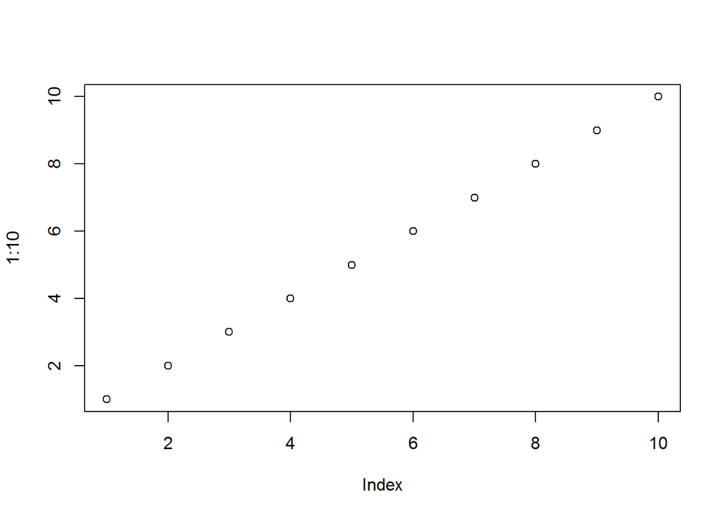

```r
> plot(1:10) #defult arguements
```

### 3.2 plot arguement

````
\```{r,fig.cap="the fig test",fig.width=3,fig.height=3}
  plot(1:10)
  fig.cap="the fig test";fig.width=3,fig.height=3
\```
````

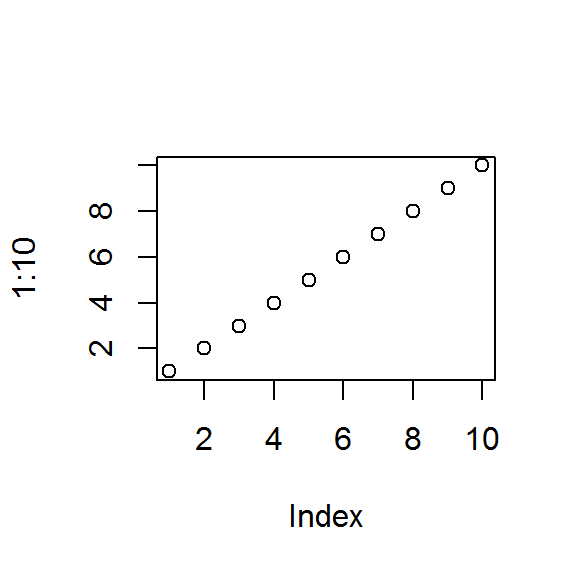

the fig test

```r
> plot(1:10)
```

```r
> #fig.cap="the fig test";fig.width=3,fig.height=3
```

Other usage need you to development!!!!!!!!!!!

# yihui’s R Markdown Document

## Okay, some R code

```r
> fit = lm(dist ~ speed, data = cars)
> b = coef(fit)  # coefficients
> summary(fit)
```

```
##
## Call:
## lm(formula = dist ~ speed, data = cars)
##
## Residuals:
##     Min      1Q  Median      3Q     Max
## -29.069  -9.525  -2.272   9.215  43.201
##
## Coefficients:
##             Estimate Std. Error t value Pr(>|t|)
## (Intercept) -17.5791     6.7584  -2.601   0.0123 *
## speed         3.9324     0.4155   9.464 1.49e-12 ***
## ---
## Signif. codes:  0 '***' 0.001 '**' 0.01 '*' 0.05 '.' 0.1 ' ' 1
##
## Residual standard error: 15.38 on 48 degrees of freedom
## Multiple R-squared:  0.6511, Adjusted R-squared:  0.6438
## F-statistic: 89.57 on 1 and 48 DF,  p-value: 1.49e-12
```

The code will be highlighted in all output formats.

## And some pictures

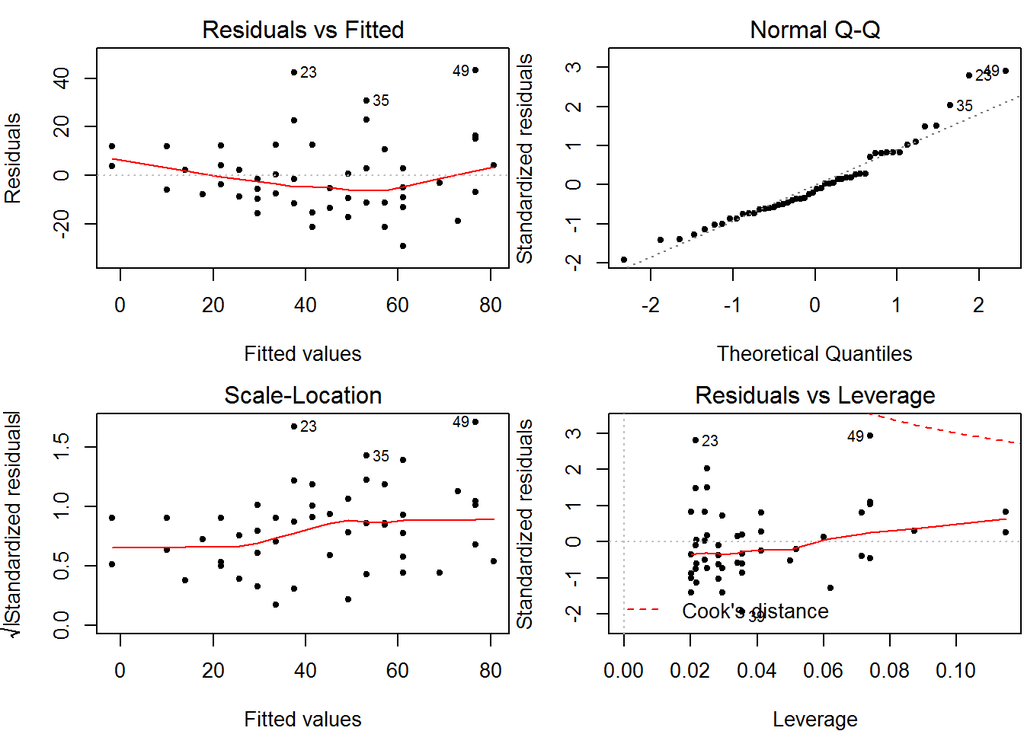

Regression diagnostics

```r
> par(mfrow = c(2, 2), pch = 20, mar = c(4, 4, 2, .1), bg = 'white')
> plot(fit)
```

## A little bit math

Our regression equation is $Y=-17.5790949+3.9324088x$, and the model is:

$$Y = \beta_0 + \beta_1 x + \epsilon$$

## Pandoc extension: definition lists

**Programmer**

A programmer is the one who turns coffee into code. LaTeX

A simple tool that is nothing but a couple of backslashes.

## Pandoc extension: examples

We have some examples.

1. Think what is `0.3 + 0.4 - 0.7`. Zero. Easy.
2. Now think what is `0.3 - 0.7 + 0.4`. Still zero?

People are often surprised by (2).

## Pandoc extension: tables

A table here.

Demonstration of simple table syntax.

| Right | Left | Center | Default |
| --- | --- | --- | --- |
| 12 | 12 | 12 | 12 |
| 123 | 123 | 123 | 123 |
| 1 | 1 | 1 | 1 |

## Pandoc extension: footnotes

We can also write footnotes[^2].

Or write some inline footnotes[^3].

## References

[^1]: A fist mall
[^2]: hi, I’m a footnote
[^3]: as you can see here